# DBnomics R client

# 12 Transform time series with filters

The **rdbnomics** package can interact with the *Time Series Editor* of DBnomics to transform time series by applying filters to them.  
Available filters are listed on the filters page https://editor.nomics.world/filters.

Here is an example of how to proceed to interpolate two annual time series with a monthly frequency, using a spline interpolation:

```r
filters <- list(
  code = "interpolate",
  parameters = list(frequency = "monthly", method = "spline")
)
```

The request is then:

```r
df <- rdb(
  ids = c("AMECO/ZUTN/EA19.1.0.0.0.ZUTN", "AMECO/ZUTN/DNK.1.0.0.0.ZUTN"),
  filters = filters
)
```

If you want to apply more than one filter, the `filters` argument will be a list of valid filters:

```r
filters <- list(
  list(
    code = "interpolate",
    parameters = list(frequency = "monthly", method = "spline")
  ),
  list(
    code = "aggregate",
    parameters = list(frequency = "bi-annual", method = "end_of_period")
  )
)

df <- rdb(
  ids = c("AMECO/ZUTN/EA19.1.0.0.0.ZUTN", "AMECO/ZUTN/DNK.1.0.0.0.ZUTN"),
  filters = filters
)
```

The `data.table` columns change a little bit when filters are used. There are two new columns:

- `period_middle_day`: the middle day of `original_period` (can be useful when you compare graphically interpolated series and original ones).
- `filtered` (boolean): `TRUE` if the series is filtered, `FALSE` otherwise.

The content of two columns are modified:

- `series_code`: same as before for original series, but the suffix `_filtered` is added for filtered series.
- `series_name`: same as before for original series, but the suffix `(filtered)` is added for filtered series.

```
##    provider_code dataset_code        dataset_name      series_code
## 1:         AMECO         ZUTN Unemployment rat... DNK.1.0.0.0.ZUTN
## 2:         AMECO         ZUTN Unemployment rat... DNK.1.0.0.0.ZUTN
## 3:         AMECO         ZUTN Unemployment rat... DNK.1.0.0.0.ZUTN
## 4:         AMECO         ZUTN Unemployment rat... DNK.1.0.0.0.ZUTN
## 5:         AMECO         ZUTN Unemployment rat... DNK.1.0.0.0.ZUTN
## 6:         AMECO         ZUTN Unemployment rat... DNK.1.0.0.0.ZUTN
##            series_name original_period     period original_value value
## 1: Annually – (Perc...            1960 1960-01-01              2   2.0
## 2: Annually – (Perc...            1961 1961-01-01            1.6   1.6
## 3: Annually – (Perc...            1962 1962-01-01            1.4   1.4
## 4: Annually – (Perc...            1963 1963-01-01              2   2.0
## 5: Annually – (Perc...            1964 1964-01-01            1.2   1.2
## 6: Annually – (Perc...            1965 1965-01-01            0.9   0.9
##    @frequency                unit                Unit geo Country freq
## 1:     annual percentage-of-ac... (Percentage of a... dnk Denmark    a
## 2:     annual percentage-of-ac... (Percentage of a... dnk Denmark    a
## 3:     annual percentage-of-ac... (Percentage of a... dnk Denmark    a
## 4:     annual percentage-of-ac... (Percentage of a... dnk Denmark    a
## 5:     annual percentage-of-ac... (Percentage of a... dnk Denmark    a
## 6:     annual percentage-of-ac... (Percentage of a... dnk Denmark    a
##    Frequency filtered          indexed_at period_middle_day
## 1:  Annually    FALSE 2019-11-08 16:33:50              <NA>
## 2:  Annually    FALSE 2019-11-08 16:33:50              <NA>
## 3:  Annually    FALSE 2019-11-08 16:33:50              <NA>
## 4:  Annually    FALSE 2019-11-08 16:33:50              <NA>
## 5:  Annually    FALSE 2019-11-08 16:33:50              <NA>
## 6:  Annually    FALSE 2019-11-08 16:33:50              <NA>
```

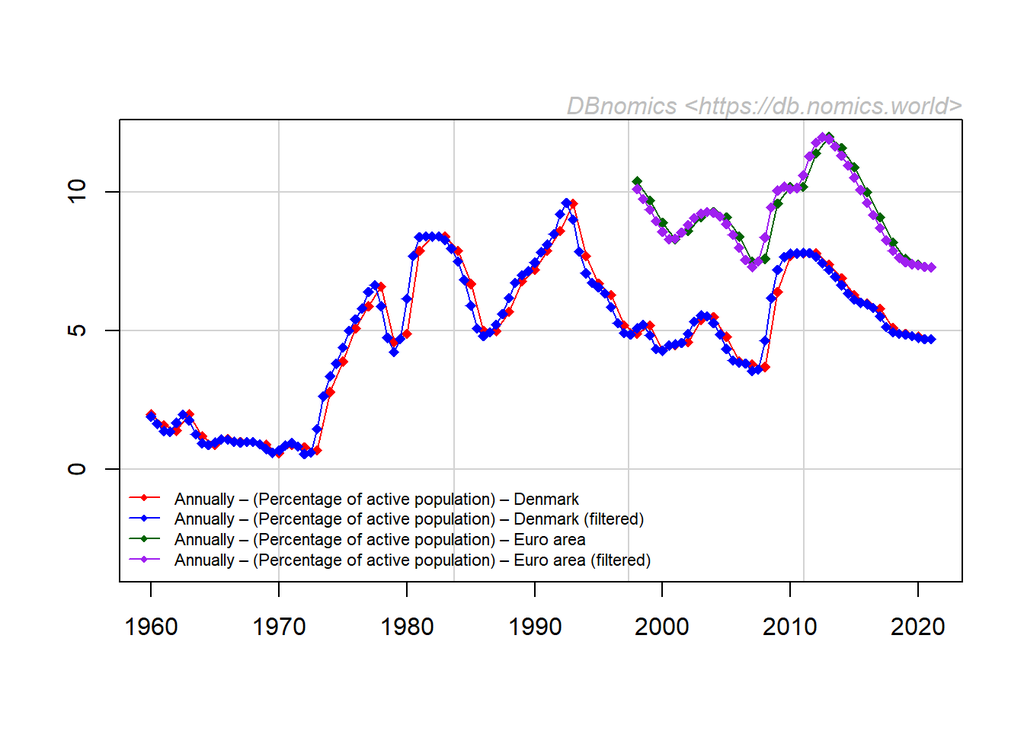

[^1]: Banque de France, https://github.com/s915
[^2]: CEPREMAP